# AS6-2

group 02

2019-03-31 21:21:07

**作業摘要:**老忠實噴泉繪圖與問題討論

- 資料檢視
- 學習重點
- 問題討論

### 內建資料集： `data(faithful)`

這是一個非常簡單的內建資料集，它只有兩個欄位：`eruptions`和`waiting`，分別紀錄了272次老忠實間歇泉的噴發時間和等待時間(分鐘數)。

### 資料結構： `str(faithful)`

```r
str(faithful)
```

```
'data.frame':   272 obs. of  2 variables:
 $ eruptions: num  3.6 1.8 3.33 2.28 4.53 ...
 $ waiting  : num  79 54 74 62 85 55 88 85 51 85 ...
```

### 簡單的統計量： `summary(faithful)`

```r
summary(faithful)
```

```
   eruptions       waiting
 Min.   :1.60   Min.   :43.0
 1st Qu.:2.16   1st Qu.:58.0
 Median :4.00   Median :76.0
 Mean   :3.49   Mean   :70.9
 3rd Qu.:4.45   3rd Qu.:82.0
 Max.   :5.10   Max.   :96.0
```

### 統計量與資料表格

下方點狀圖除了呈現個別變數的分佈狀況之外，也可以幫助我們觀察兩個變數之間的關係；這個章節我們先討論單一變數的分佈，我們會等到回歸分析的章節再跟大家討論變數之間的關係。

### 資料表格

```r
renderDataTable({
  datatable(
    faithful, extensions=c('Scroller','ColReorder'), options=list(
      deferRender=T, scrollY=200, scroller=T, colReorder=T)) %>%
  formatStyle(columns=0:2, fontSize = '80%')
  })
```

[output not shown]

### 點狀圖

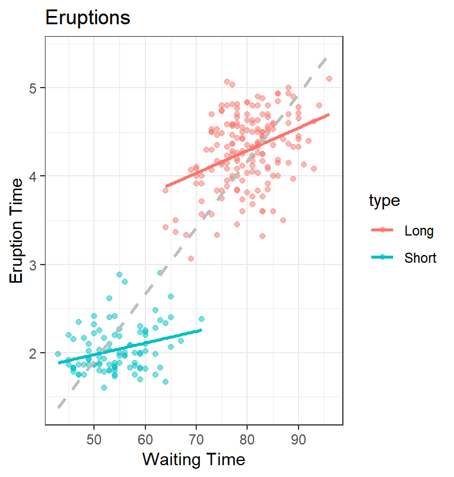

```r
mutate(faithful, type = ifelse(eruptions > 3, "Long", "Short")) %>%
  ggplot(aes(waiting, eruptions, col=type)) +
    geom_point(alpha=0.5) +
    geom_smooth(method='lm', se=F) +
    geom_smooth(method='lm', se=F, col="gray", lty=2) +
    xlab("Waiting Time") + ylab("Eruption Time") +
    ggtitle("Eruptions") + theme_bw()
```